# Tugas Pertemuan 3 - Analisis ARDL Data Curah Hujan

Arifatu Dzikra

2026-09-07

# 1 Library

Tahap ini memuat seluruh pustaka (library) R yang diperlukan untuk pengolahan data deret waktu, eksplorasi statistik, visualisasi, hingga pemodelan ARDL.

```r
library(readxl)
library(dplyr)
library(ggplot2)
library(moments)
library(ggcorrplot)
library(corrplot)
library(forecast)
library(urca)
library(tseries)
library(dynlm)
library(dLagM)
library(lmtest)
library(car)
library(ARDL)
library(tidyr)
library(MASS)
library(patchwork)
library(nardl)
library(writexl)
library(openxlsx)
library(dynamac)
library(e1071)
library(MLmetrics)
library(ivreg)
```

Pustaka-pustaka di atas diaktifkan secara simultan untuk mendukung seluruh tahapan analisis dari eksplorasi hingga evaluasi model.

# 2 Import Data

Tahap ini mengimpor dataset harian dari file Excel lokal ke dalam lingkungan R dan membatasi variabel menjadi peubah terikat tunggal yaitu Tinggi Muka Air ($\text{TMA}$) sebagai $Y$ dan peubah bebas tunggal yaitu Curah Hujan ($\text{PC}$) sebagai $X$.

```r
dataset <- read_excel("D:/IPB UNIVERSITY/KULIAH/SEMESTER 5/MPDW/Metode Peramalan Deret Waktu/Pertemuan 3/Data_Harian_2022_2024.xlsx")
data_sub <- dataset %>%
  dplyr::select(Date, TMA, PC) %>%
  rename(Yt = TMA, Xt = PC)
str(data_sub)
```

```
## tibble [1,096 × 3] (S3: tbl_df/tbl/data.frame)
##  $ Date: POSIXct[1:1096], format: "2022-01-01" "2022-01-02" ...
##  $ Yt  : num [1:1096] 595 588 580 576 574 ...
##  $ Xt  : num [1:1096] 0.85 1.79 0.4 0.22 5.7 ...
```

# 3 Eksplorasi Data

```r
summary(data_sub[, c("Yt", "Xt")])
```

```
##        Yt              Xt
##  Min.   :555.4   Min.   :  0.0000
##  1st Qu.:597.7   1st Qu.:  0.7375
##  Median :620.0   Median :  4.0000
##  Mean   :625.3   Mean   :  6.5700
##  3rd Qu.:650.1   3rd Qu.:  9.1325
##  Max.   :781.2   Max.   :145.0300
```

### 3.0.1 Standard Deviation

Tahap ini menghitung simpangan baku untuk mengetahui tingkat keragaman data harian pada peubah $\text{TMA}$ dan $\text{PC}$.

```r
sd_tma <- sd(data_sub$Yt, na.rm = TRUE)
sd_pc <- sd(data_sub$Xt, na.rm = TRUE)
cat("Standard Deviation TMA:", sd_tma, "\n")
```

```
## Standard Deviation TMA: 39.44962
```

```r
cat("Standard Deviation PC:", sd_pc, "\n")
```

```
## Standard Deviation PC: 8.838259
```

### 3.0.2 Skewness

Tahap ini menghitung koefisien kemencengan (skewness) untuk mengevaluasi tingkat kesimetrisan distribusi data peubah $\text{TMA}$ dan $\text{PC}$.

```r
skew_tma <- skewness(data_sub$Yt, na.rm = TRUE)
skew_pc <- skewness(data_sub$Xt, na.rm = TRUE)
cat("Skewness TMA:", skew_tma, "\n")
```

```
## Skewness TMA: 0.5297495
```

```r
cat("Skewness PC:", skew_pc, "\n")
```

```
## Skewness PC: 5.063932
```

- Jika skewness $\approx 0$, berarti distribusi simetris.
- Curah Hujan ($\text{PC}$) memiliki nilai skewness yang tinggi dan bernilai positif, menandakan distribusi data sangat miring ke kanan (right-skewed) akibat adanya hari-hari dengan curah hujan ekstrem.

### 3.0.3 Kurtosis

Tahap ini menghitung nilai kurtosis guna mengetahui tingkat keruncingan distribusi peubah $\text{TMA}$ dan $\text{PC}$.

```r
kurt_tma <- kurtosis(data_sub$Yt, na.rm = TRUE)
kurt_pc <- kurtosis(data_sub$Xt, na.rm = TRUE)
cat("Kurtosis TMA:", kurt_tma, "\n")
```

```
## Kurtosis TMA: -0.02103916
```

```r
cat("Kurtosis PC:", kurt_pc, "\n")
```

```
## Kurtosis PC: 59.08334
```

## 3.1 Plot Time Series TMA dan PC

Tahap ini menyajikan grafik garis deret waktu untuk melihat pola pergerakan harian dari peubah $\text{TMA}$ dan $\text{PC}$ secara visual.

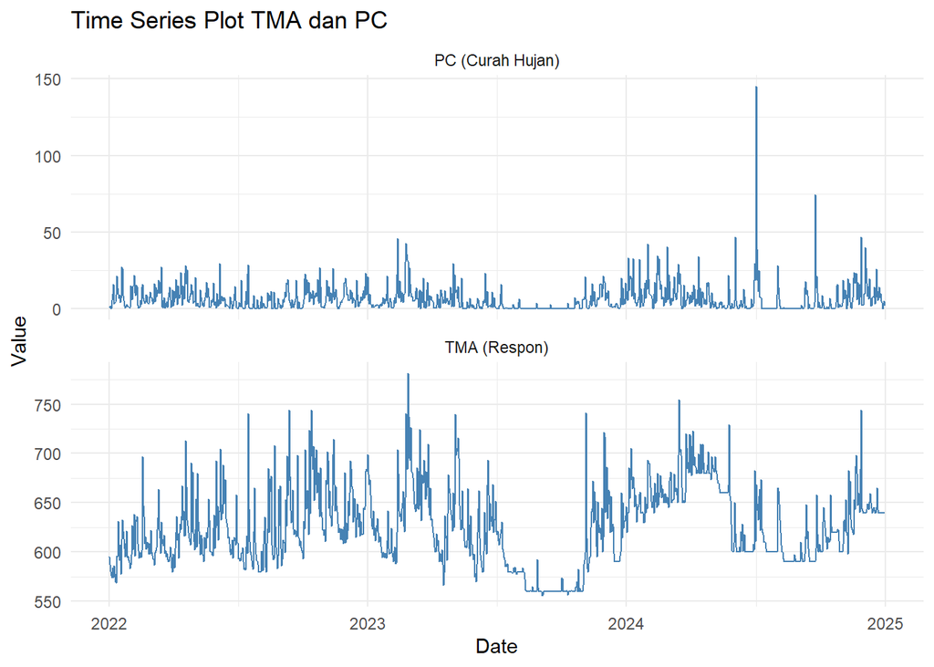

```r
data_long <- data_sub %>%
  pivot_longer(cols = c(Yt, Xt),
               names_to = "Variabel",
               values_to = "Nilai") %>%
  mutate(Variabel = ifelse(Variabel == "Yt", "TMA (Respon)", "PC (Curah Hujan)"))

ggplot(data_long, aes(x = Date, y = Nilai)) +
  geom_line(color = "steelblue") +
  facet_wrap(~ Variabel, scales = "free_y", ncol = 1) +
  labs(title = "Time Series Plot TMA dan PC",
       x = "Date",
       y = "Value") +
  theme_minimal()
```

- Berdasarkan plot time series di atas, peubah Curah Hujan ($\text{PC}$) menunjukkan fluktuasi yang konstan di sekitar nilai rendah dengan beberapa lonjakan ekstrem yang tajam secara berkala.
- Peubah Tinggi Muka Air ($\text{TMA}$) memperlihatkan pola pergerakan naik turun yang berfluktuasi sepanjang waktu tanpa tren linier yang kaku, mengindikasikan adanya dinamika merespon kondisi musim atau curah hujan.

## 3.2 Matriks Korelasi

Pemeriksaan korelasi linear sederhana dilakukan untuk melihat sejauh mana hubungan awal antara peubah bebas dan peubah terikat.

```r
cor_val <- cor(data_sub$Yt, data_sub$Xt, use = "complete.obs")
cat("Koefisien Korelasi antara TMA dan PC:", cor_val, "\n")
```

```
## Koefisien Korelasi antara TMA dan PC: 0.3945932
```

- Berdasarkan perhitungan di atas, diperoleh nilai koefisien korelasi antara Tinggi Muka Air ($\text{TMA}$) dan Curah Hujan ($\text{PC}$) sebesar $0,3946$.
- Nilai korelasi positif menunjukkan adanya hubungan searah yang moderat antara besarnya curah hujan harian dengan kenaikan tinggi muka air.

# 4 Data Splitting

Bagian ini membagi keseluruhan dataset menjadi data pelatihan (train) dan data pengujian (test) dengan proporsi tertentu untuk keperluan evaluasi model peramalan.

```r
total_rows <- nrow(data_sub)
test_size <- 153

train_index <- 1:(total_rows - test_size)
test_index  <- (total_rows - test_size + 1):total_rows

train <- data_sub[train_index, ]
test  <- data_sub[test_index, ]

cat("Jumlah data train:", nrow(train), "\n")
```

```
## Jumlah data train: 943
```

```r
cat("Jumlah data test:", nrow(test), "\n")
```

```
## Jumlah data test: 153
```

- Berdasarkan pola data, data dibagi menjadi data train sebesar $86\%$ dari total data atau sebanyak $943$ data dan data test sebesar $14\%$ dari total data atau sebanyak $153$ data.

**Time Series Data Split Plot** *Plot Time Series Gabungan (TMA dan PC) Train vs Test* Tahap ini memvisualisasikan pembagian data latih dan data uji pada peubah $\text{TMA}$ dan $\text{PC}$.

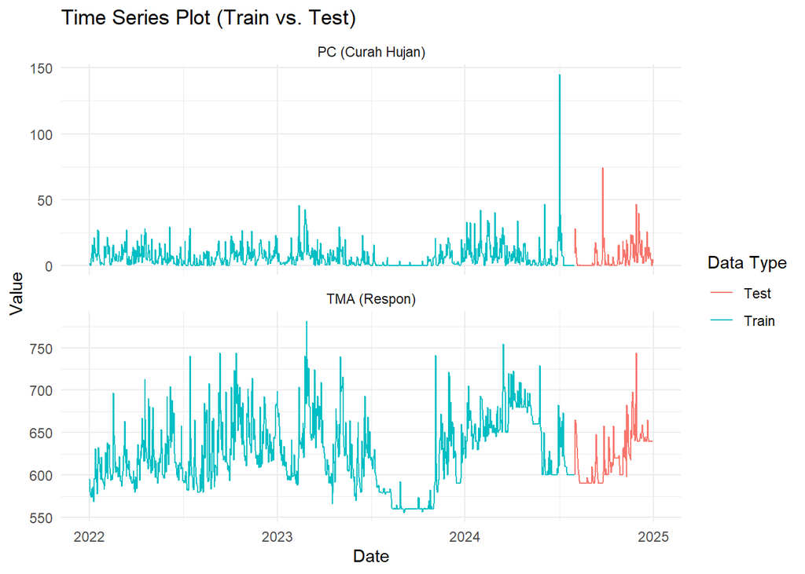

```r
combined_data <- bind_rows(
  train %>% mutate(DataType = "Train"),
  test %>% mutate(DataType = "Test")
)

data_long_split <- combined_data %>%
  dplyr::select(Date, Yt, Xt, DataType) %>%
  pivot_longer(
    cols = c(Yt, Xt),
    names_to = "Variabel",
    values_to = "Nilai"
  ) %>%
  mutate(Variabel = ifelse(Variabel == "Yt", "TMA (Respon)", "PC (Curah Hujan)"))

ggplot(data_long_split, aes(x = Date, y = Nilai, color = DataType)) +
  geom_line() +
  facet_wrap(~ Variabel, scales = "free_y", ncol = 1) +
  scale_color_manual(
    values = c("Train" = "#00BFC4", "Test" = "#F8766D")
  ) +
  labs(
    title = "Time Series Plot (Train vs. Test)",
    x = "Date",
    y = "Value",
    color = "Data Type"
  ) +
  theme_minimal()
```

# 5 Kestasioneran Data dan CCF

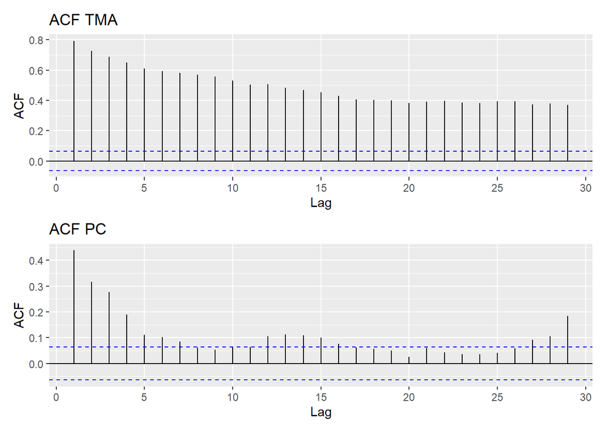

```r
acf_TMA <- ggAcf(train$Yt) + labs(title = "ACF TMA")
acf_PC <- ggAcf(train$Xt) + labs(title = "ACF PC")

combined_acf <- acf_TMA / acf_PC
combined_acf
```

## 5.1 Plot PACF TMA dan PC

Tahap ini menampilkan plot Partial Autocorrelation Function (PACF) untuk peubah $\text{TMA}$ dan $\text{PC}$.

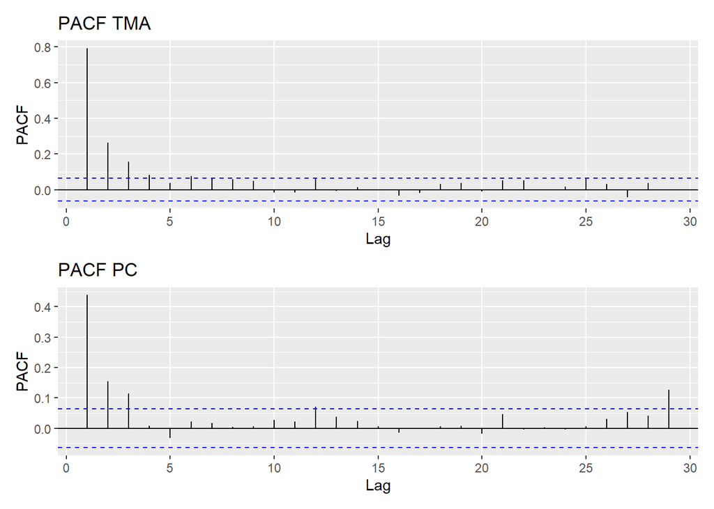

```r
pacf_TMA <- ggPacf(train$Yt) + labs(title = "PACF TMA")
pacf_PC <- ggPacf(train$Xt) + labs(title = "PACF PC")

combined_pacf <- pacf_TMA / pacf_PC
combined_pacf
```

## 5.2 Uji ADF

```r
adf.test(train$Yt)
```

```
##
##  Augmented Dickey-Fuller Test
##
## data:  train$Yt
## Dickey-Fuller = -4.0051, Lag order = 9, p-value = 0.01
## alternative hypothesis: stationary
```

TMA stasioner secara uji formal

### 5.2.1 PC

```r
adf.test(train$Xt)
```

```
##
##  Augmented Dickey-Fuller Test
##
## data:  train$Xt
## Dickey-Fuller = -7.5359, Lag order = 9, p-value = 0.01
## alternative hypothesis: stationary
```

PC stasioner secara uji formal.

## 5.3 Plot CCF antara TMA dan PC

Tahap ini melihat korelasi silang antara peubah $\text{TMA}$ dan $\text{PC}$ pada berbagai lag waktu.

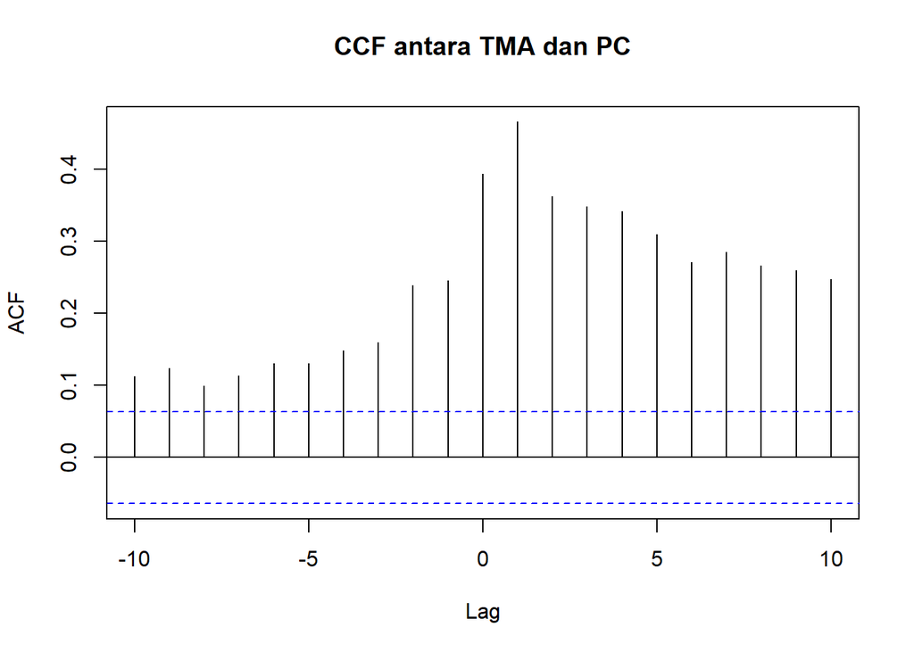

```r
ccf_result <- ccf(train$Yt, train$Xt, lag.max = 10, plot = TRUE, main = "CCF antara TMA dan PC")
```

Berdasarkan plot Cross-Correlation Function (CCF) di atas, terlihat adanya signifikansi korelasi silang antara $\text{TMA}$ dan $\text{PC}$ pada beberapa lag, yang mengindikasikan bahwa peubah penjelas ($\text{PC}$) memiliki hubungan keterlambatan waktu terhadap peubah respon ($\text{TMA}$).

# 6 First Difference

## 6.1 Differencing

```r
DTMA <- diff(train$Yt, differences = 1)
DPC <- diff(train$Xt, differences = 1)
df <- data.frame(DTMA, DPC)
df.ts <- ts(df)
head(df)
```

|  | DTMA | DPC |
| --- | --- | --- |
| 1 | -7.708333 | 0.94 |
| 2 | -7.500000 | -1.39 |
| 3 | -4.375000 | -0.18 |
| 4 | -1.458333 | 5.48 |
| 5 | 9.583333 | 3.75 |
| 6 | -10.208333 | 6.72 |

## 6.2 Plot ACF

### 6.2.1 DTMA

Tahap ini menampilkan plot ACF untuk peubah $\text{DTMA}$ hasil differencing pertama.

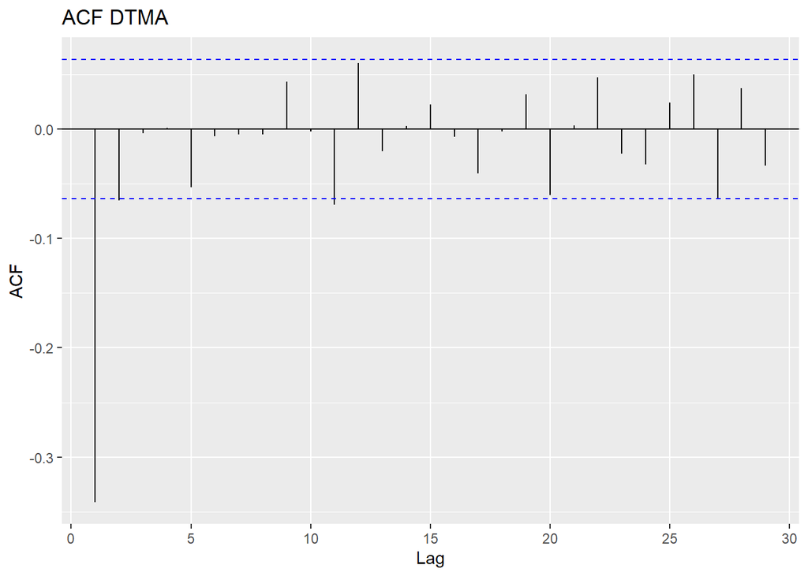

```r
acf_DTMA <- ggAcf(DTMA) + labs(title = "ACF DTMA")
acf_DTMA
```

Plot ACF DTMA tidak menurun secara perlahan : TMA stasioner

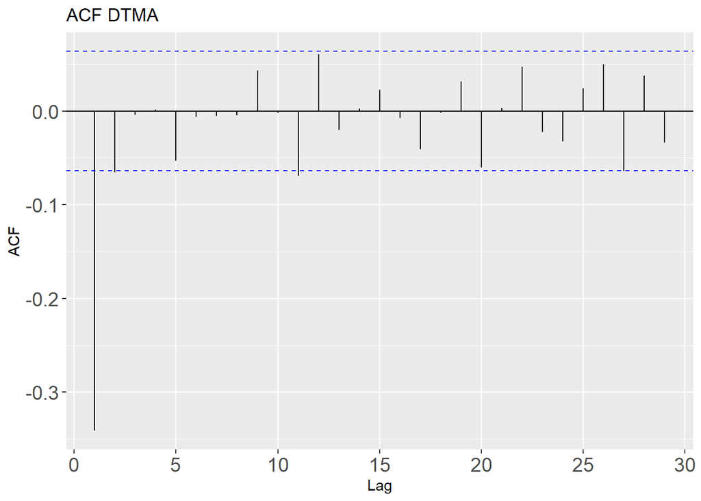

```r
acf_DTMA <- ggAcf(DTMA) +
  labs(title = "ACF DTMA") +
  theme(
    axis.text.x = element_text(size = 14),
    axis.text.y = element_text(size = 14)
  )
acf_DTMA
```

Plot ACF DTMA tidak menurun secara perlahan, yang mengindikasikan bahwa data $\text{DTMA}$ telah stasioner dalam rata-rata.

### 6.2.2 DPC

Tahap ini menampilkan plot ACF untuk peubah $\text{DPC}$ hasil differencing pertama.

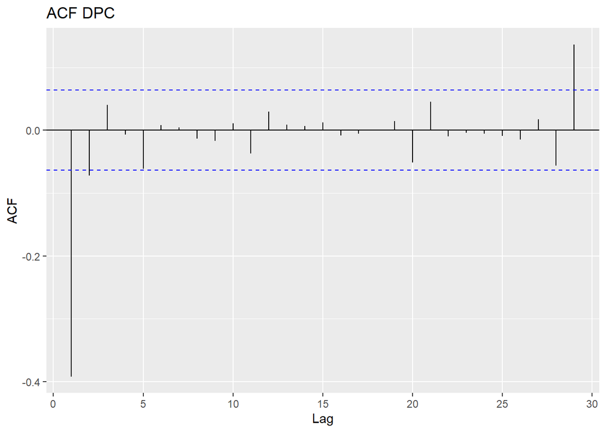

```r
acf_DPC <- ggAcf(DPC) + labs(title = "ACF DPC")
acf_DPC
```

Plot ACF DPC tidak menurun secara perlahan: PC stasioner

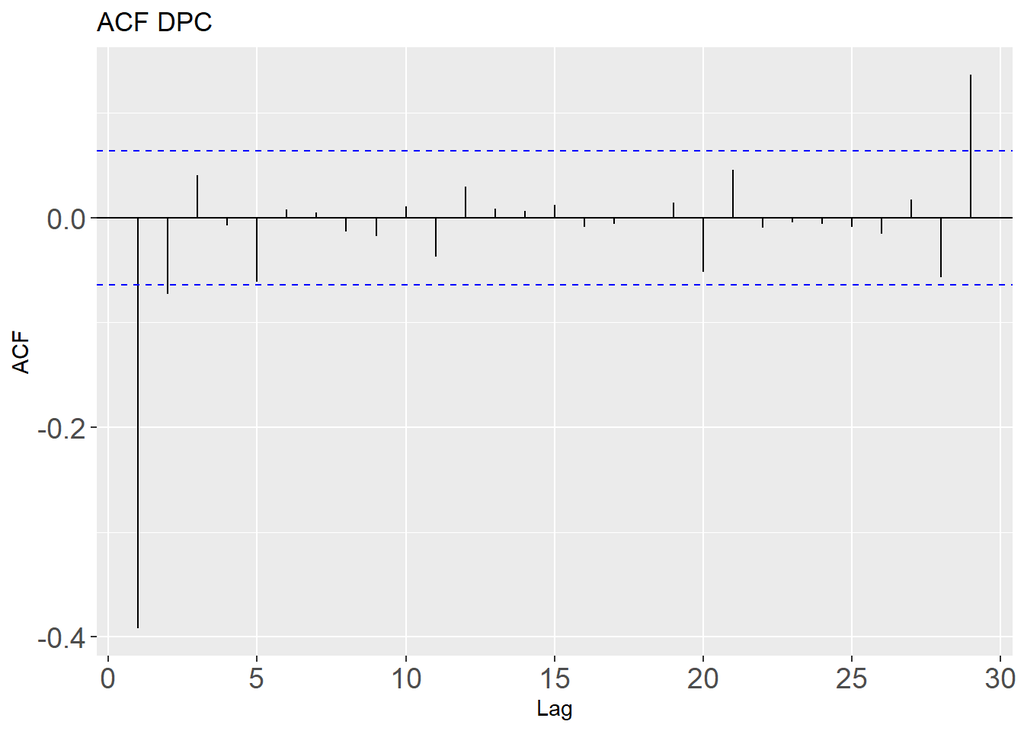

```r
acf_DPC <- ggAcf(DPC) +
  labs(title = "ACF DPC") +
  theme(
    axis.text.x = element_text(size = 14),
    axis.text.y = element_text(size = 14)
  )
acf_DPC
```

Plot ACF DPC tidak menurun secara perlahan, yang mengindikasikan bahwa data $\text{DPC}$ telah stasioner dalam rata-rata.

## 6.3 Plot PACF

### 6.3.1 DTMA

Tahap ini menampilkan plot PACF untuk peubah $\text{DTMA}$ hasil differencing pertama.

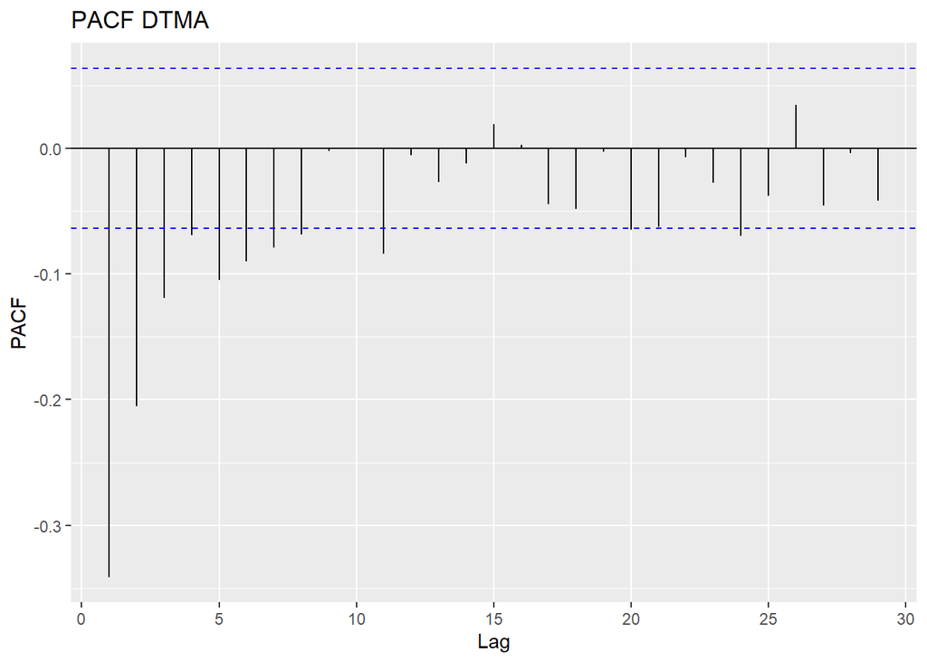

```r
pacf_DTMA <- ggPacf(DTMA) + labs(title = "PACF DTMA")
pacf_DTMA
```

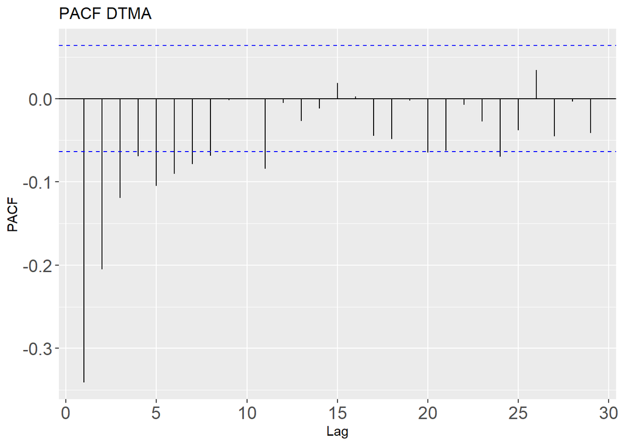

```r
pacf_DTMA <- ggPacf(DTMA) +
  labs(title = "PACF DTMA") +
  theme(
    axis.text.x = element_text(size = 14),
    axis.text.y = element_text(size = 14)
  )
pacf_DTMA
```

Lag $p$ antara $1$ sampai $8$, karena PACF memotong (cut-off) setelah lag-$8$.

### 6.3.2 DPC

Tahap ini menampilkan plot PACF untuk peubah $\text{DPC}$ hasil differencing pertama.

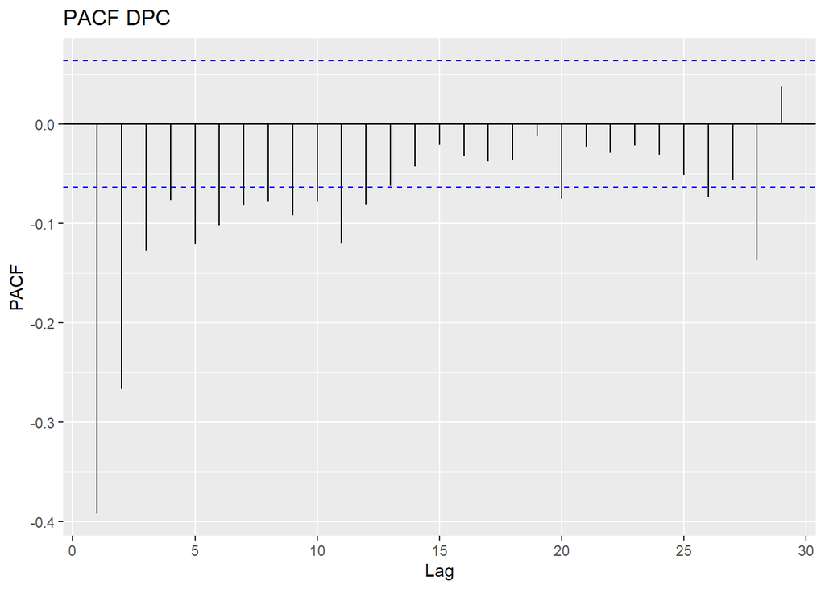

```r
pacf_DPC <- ggPacf(DPC) + labs(title = "PACF DPC")
pacf_DPC
```

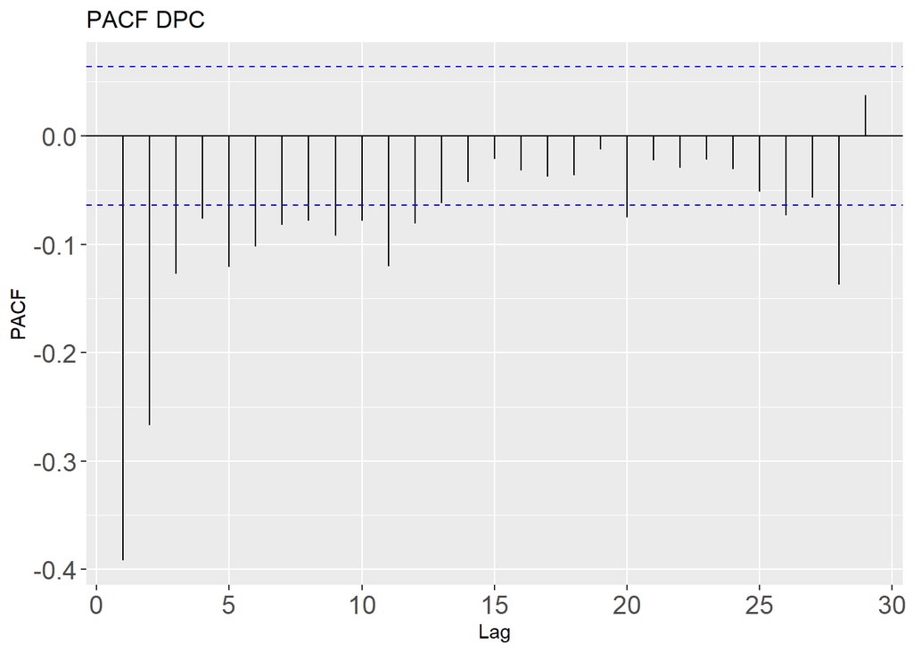

```r
pacf_DPC <- ggPacf(DPC) +
  labs(title = "PACF DPC") +
  theme(
    axis.text.x = element_text(size = 14),
    axis.text.y = element_text(size = 14)
  )
pacf_DPC
```

Berdasarkan plot PACF untuk peubah $\text{DPC}$, terlihat pola pemotongan (cut-off) pada beberapa lag awal yang mengindikasikan komponen autoregressive (AR) pada data yang telah dibedakan.

## 6.4 Uji ADF

### 6.4.1 DTMA

Tahap ini melakukan uji Augmented Dickey-Fuller (ADF) untuk peubah $\text{DTMA}$ guna menguji kestasioneran secara formal setelah differencing pertama.

```r
adf.test(DTMA)
```

```
##
##  Augmented Dickey-Fuller Test
##
## data:  DTMA
## Dickey-Fuller = -12.566, Lag order = 9, p-value = 0.01
## alternative hypothesis: stationary
```

Nilai p-value sebesar $0.01$ (lebih kecil dari taraf nyata $\alpha = 0.05$), sehingga tolak $H_0$. Hal ini menunjukkan bahwa peubah $\text{TMA}$ (DTMA) sudah stasioner secara uji formal.

### 6.4.2 DPC

Tahap ini melakukan uji Augmented Dickey-Fuller (ADF) untuk peubah $\text{DPC}$ guna menguji kestasioneran secara formal setelah differencing pertama.

```r
adf.test(DPC)
```

```
##
##  Augmented Dickey-Fuller Test
##
## data:  DPC
## Dickey-Fuller = -15.041, Lag order = 9, p-value = 0.01
## alternative hypothesis: stationary
```

Nilai p-value sebesar $0.01$ (lebih kecil dari taraf nyata $\alpha = 0.05$), sehingga tolak $H_0$. Hal ini menunjukkan bahwa peubah $\text{PC}$ (DPC) sudah stasioner secara uji formal.

## 6.5 Plot CCF (Lag Optimum Peubah Penjelas)

Tahap ini menampilkan plot *Cross-Correlation Function* (CCF) antara peubah $\text{DTMA}$ dan $\text{DPC}$ untuk menentukan lag optimum dari peubah penjelas. **Plot**

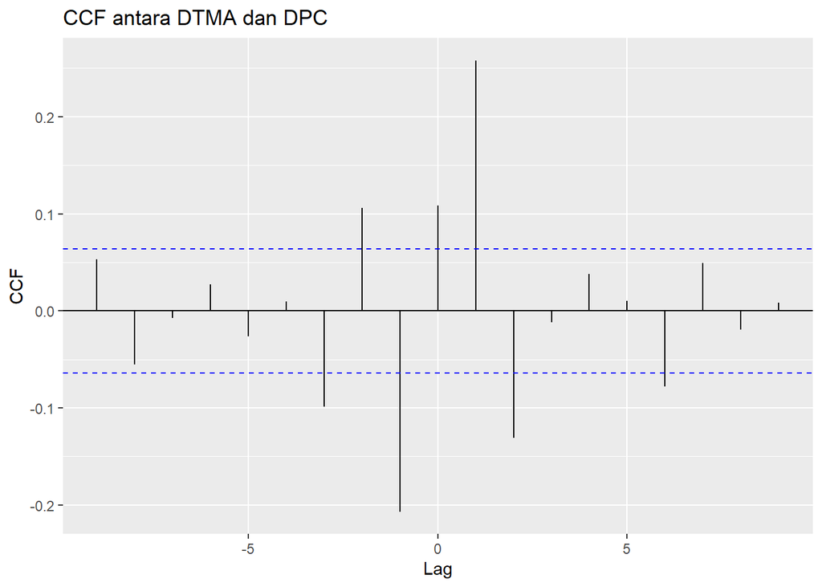

```r
ccf_result1 <- ggCcf(DTMA, DPC, lag.max=9) + ggtitle("CCF antara DTMA dan DPC")
ccf_result1
```

Lag optimum $q_1 = 1$

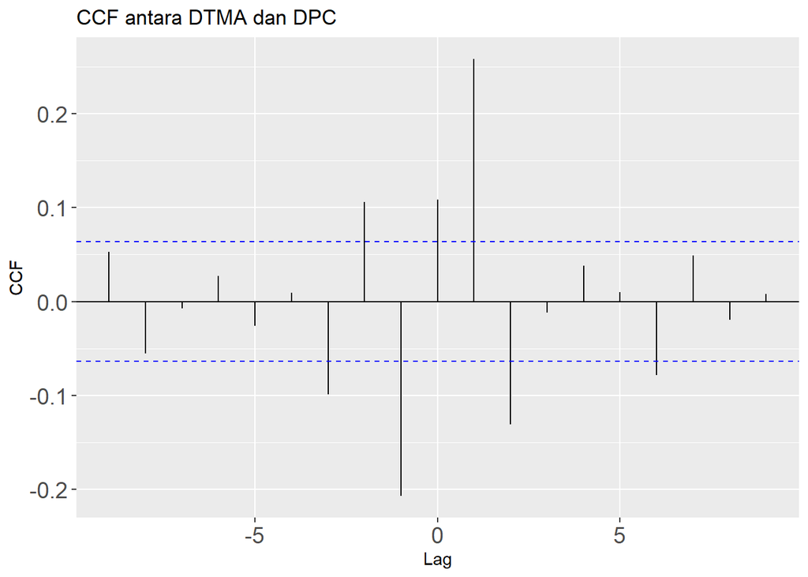

```r
ccf_result1 <- ggCcf(DTMA, DPC, lag.max = 9) +
  ggtitle("CCF antara DTMA dan DPC") +
  theme(
    axis.text.x = element_text(size = 14),
    axis.text.y = element_text(size = 14)
  )
ccf_result1
```

**Nilai Korelasi**

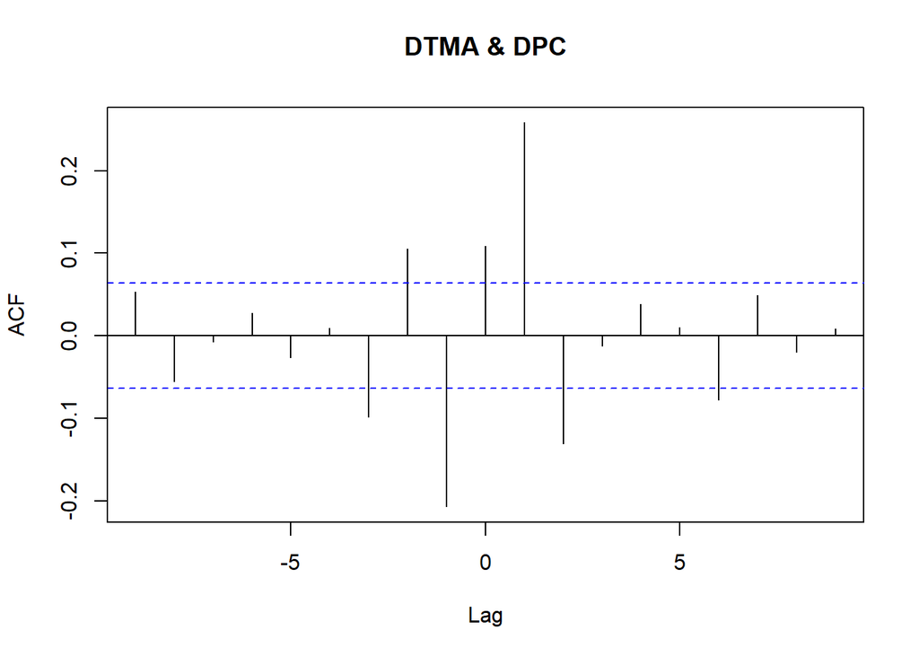

```r
ccf_result1 <- ccf(DTMA, DPC, lag.max=9, plot = TRUE)
```

Berdasarkan plot CCF antara peubah $\text{DTMA}$ dan $\text{DPC}$ dengan lag.max sebesar $9$, diperoleh lag optimum peubah penjelas $q_1 = 1$ yang berada di luar batas signifikansi (garis putus-putus biru), menunjukkan adanya hubungan keterlambatan (lag) yang signifikan antara peubah respon dan peubah penjelas setelah dilakukan pembedaan (differencing).

# 7 Model Distributed Lag (DLM)

## 7.1 Pemodelan DLM

Tahap ini memodelkan hubungan keterlambatan waktu menggunakan *Distributed Lag Model* (DLM). Pada kerangka kerja DLM, peubah respon (perubahan Tinggi Muka Air / $\text{DTMA}$) dipengaruhi oleh peubah penjelas (perubahan Curah Hujan / $\text{DPC}$) pada periode saat ini ($t$) serta periode-periode sebelumnya ($t-q$). Berdasarkan identifikasi fungsi korelasi silang (*Cross-Correlation Function* / CCF) pada tahap sebelumnya, diperoleh lag optimum peubah penjelas yaitu $q = 1$. Pembentukan model menggunakan data hasil pembedaan pertama (*first differencing*) guna menjamin kestasioneran data.

```r
model_dlm <- dlm(x = as.vector(DPC), y = as.vector(DTMA), q = 1)
summary(model_dlm$model)
```

```
##
## Call:
## lm(formula = model.formula, data = design)
##
## Residuals:
##      Min       1Q   Median       3Q      Max
## -108.387   -9.656   -0.435    7.632  138.664
##
## Coefficients:
##             Estimate Std. Error t value Pr(>|t|)
## (Intercept)  0.01530    0.80867   0.019    0.985
## x.t          0.71077    0.09552   7.441 2.25e-13 ***
## x.1          1.01849    0.09552  10.663  < 2e-16 ***
## ---
## Signif. codes:  0 '***' 0.001 '**' 0.01 '*' 0.05 '.' 0.1 ' ' 1
##
## Residual standard error: 24.81 on 938 degrees of freedom
## Multiple R-squared:  0.1186, Adjusted R-squared:  0.1168
## F-statistic: 63.14 on 2 and 938 DF,  p-value: < 2.2e-16
```

1. **Persamaan Model:** Berdasarkan output di atas, persamaan regresi DLM dengan $q = 1$ yang terbentuk dapat dituliskan sebagai berikut:

$$\widehat{\text{DTMA}}_t = 0.01530 +
0.71077\,\text{DPC}_t + 1.01849\,\text{DPC}_{t-1}$$

2. **Penguji Koefisien Individu (Uji t):**
   - **Intersep ($0.01530$):** Nilai p-value sebesar $0.985 > 0.05$ menunjukkan bahwa intersep tidak berpengaruh signifikan secara statistik terhadap model.
   - **Curah Hujan Saat Ini / $x.t$ ($0.71077$):** Nilai p-value sebesar $2.25 \times 10^{-13} < 0.05$ (sangat signifikan pada $\alpha = 5\%$). Hal ini mengindikasikan bahwa setiap kenaikan $1$ unit curah hujan pada hari ini secara langsung meningkatkan Tinggi Muka Air sebesar $0.71077$ unit pada hari yang sama.
   - **Curah Hujan Kemarin / $x.1$ ($1.01849$):** Nilai p-value $< 2 \times 10^{-16} < 0.05$ (sangat signifikan pada $\alpha = 5\%$). Koefisien ini menunjukkan bahwa curah hujan $1$ hari sebelumnya memberikan dampak positif terhadap kenaikan Tinggi Muka Air hari ini sebesar $1.01849$ unit. Menariknya, dampak curah hujan hari sebelumnya ($1.01849$) lebih besar dibandingkan dampak curah hujan pada hari yang sama ($0.71077$).
3. **Uji Keberartian Model Secara Simultan (Uji F):** Diperoleh nilai F-statistik sebesar $63.14$ dengan p-value $< 2.2 \times 10^{-16} < 0.05$. Hal ini menunjukkan keputusan Tolak $H_0$, yang berarti peubah curah hujan saat ini ($\text{DPC}_t$) dan curah hujan hari sebelumnya ($\text{DPC}_{t-1}$) secara bersama-sama (simultan) berpengaruh signifikan terhadap fluktuasi perubahan Tinggi Muka Air ($\text{DTMA}_t$).
4. **Koefisien Determinasi ($R^2$):** Nilai Multiple R-squared sebesar $0.1186$ (dan Adjusted R-squared sebesar $0.1168$). Hal ini mengindikasikan bahwa sekitar $11.86\%$ keragaman perubahan Tinggi Muka Air mampu dijelaskan oleh variabel curah hujan saat ini dan $1$ hari sebelumnya melalui model DLM. Adapun $88.14\%$ sisanya dipengaruhi oleh faktor-faktor lain di luar model.

## 7.2 Evaluasi Model DLM

Tahap ini mengevaluasi kinerja dan kriteria kebaikan model (Goodness of Fit) DLM. Evaluasi dilakukan dengan menghitung nilai kriteria informasi Akaike Information Criterion (AIC) dan Bayesian Information Criterion (BIC), serta mengekstrak metrik kesalahan peramalan in-sample (seperti MAE dan MSE) pada data latih. Nilai-nilai ini berfungsi sebagai benchmark komparatif untuk dibandingkan dengan model deret waktu lainnya.

```r
# Menampilkan nilai AIC, BIC, dan Akurasi (GoF)
cat("AIC DLM:", AIC(model_dlm$model), "\n")
```

```
## AIC DLM: 8718.745
```

```r
cat("BIC DLM:", BIC(model_dlm$model), "\n")
```

```
## BIC DLM: 8738.133
```

```r
# Menghitung Goodness of Fit (MAPE, MAE, dsb) pada data latih
GoF(model_dlm)
```

|  | n | MAE | MPE | MAPE | sMAPE | MASE | MSE | MRAE | GMRAE |
| --- | --- | --- | --- | --- | --- | --- | --- | --- | --- |
| model_dlm | 941 | 15.77835 | NaN | Inf | 1.535554 | 0.5764154 | 613.4048 | 951195863 | 5.180658 |

1. **Kriteria Informasi Model:**
   - Nilai AIC: $8718.745$
   - Nilai BIC: $8738.133$
   - Nilai AIC dan BIC ini menjadi patokan evaluasi. Semakin kecil nilai AIC/BIC, semakin efisien model dalam merangkum informasi data tanpa risiko overfitting.
2. **Tingkat Kesalahan Model (Goodness of Fit):**
   - Jumlah Observasi ($n$): $941$ data latih.
   - Mean Absolute Error (MAE): $15.77835$, artinya secara rata-rata deviasi absolut antara nilai dugaan dan nilai aktual Tinggi Muka Air pada model DLM adalah sebesar $15.78$ unit.
   - Mean Squared Error (MSE): $613.4048$.
   - Mean Absolute Scaled Error (MASE): $0.5764154$.

# 8 Model Autoregressive Lag (ARL/Koyck)

## 8.1 Pemodelan ARL

Tahap ini memodelkan hubungan dinamik antara Tinggi Muka Air dan Curah Hujan menggunakan *Model Autoregressive Lag* (ARL) atau yang dikenal sebagai *Model Koyck*. Berbeda dengan DLM yang hanya memasukkan *lag* peubah independen, model ARL memasukkan unsur *lag* dari peubah respon itu sendiri ($\text{DTMA}_{t-1}$) sebagai penjelas di samping peubah independen saat ini ($\text{DPC}_t$). Pendekatan Koyck mengasumsikan bahwa pengaruh *lag* peubah bebas meluruh secara eksponensial seiring bertambahnya waktu. Model diestimasi menggunakan metode *Instrumental Variable* (IV) melalui fungsi `koyckDlm()`.

```r
model_koyck <- koyckDlm(x = as.vector(DPC), y = as.vector(DTMA))
summary(model_koyck$model)
```

```
##
## Call:
## "Y ~ (Intercept) + Y.1 + X.t"
##
## Residuals:
##      Min       1Q   Median       3Q      Max
## -232.759  -16.173   -1.249   10.972  310.149
##
## Coefficients:
##             Estimate Std. Error t value Pr(>|t|)
## (Intercept)  0.01127    1.07451   0.010    0.992
## Y.1         -0.50644    0.04662 -10.864  < 2e-16 ***
## X.t         -2.29141    0.31430  -7.291 6.55e-13 ***
## ---
## Signif. codes:  0 '***' 0.001 '**' 0.01 '*' 0.05 '.' 0.1 ' ' 1
##
## Residual standard error: 32.96 on 938 degrees of freedom
## Multiple R-Squared: -0.5561, Adjusted R-squared: -0.5594
## Wald test: 61.65 on 2 and 938 DF,  p-value: < 2.2e-16
```

1. **Persamaan Model:** Berdasarkan output hasil estimasi regresi variabel instrumental di atas, persamaan model Koyck yang terbentuk adalah:

$$\widehat{\text{DTMA}}_t = 0.01127 -
0.50644\,\text{DTMA}_{t-1} - 2.29141\,\text{DPC}_t$$

2. **Pengujian Koefisien Individu (Uji t):**
   - **Intersep ($0.01127$):** Nilai p-value sebesar $0.992 > 0.05$ menunjukkan bahwa intersep tidak berpengaruh signifikan secara statistik terhadap model.
   - **Lag Respon / $Y.1$ ($-0.50644$):** Nilai p-value $< 2 \times 10^{-16} < 0.05$ (sangat signifikan pada $\alpha = 5\%$). Koefisien ini menggambarkan parameter struktur autokorelasi Koyck ($\lambda$). Hasil negatif mengindikasikan adanya koreksi nilai peubah respon dari periode sebelumnya terhadap perubahan tinggi muka air hari ini.
   - **Curah Hujan Saat Ini / $x.t$ ($-2.29141$):** Nilai p-value sebesar $6.55 \times 10^{-13} < 0.05$ (sangat signifikan pada $\alpha = 5\%$). Hal ini mengindikasikan bahwa peubah curah hujan saat ini memberikan pengaruh nyata terhadap perubahan tinggi muka air dalam kerangka transformasi Koyck.
3. **Uji Keberartian Model secara Simultan (Wald Test):** Uji statistik Wald menghasilkan nilai statistik sebesar $61.65$ dengan p-value $< 2.2 \times 10^{-16} < 0.05$. Hal ini menunjukkan keputusan Tolak $H_0$, yang berarti peubah lag tinggi muka air ($\text{DTMA}_{t-1}$) dan curah hujan saat ini ($\text{DPC}_t$) secara simultan berpengaruh signifikan terhadap peubah respon.
4. **Koefisien Determinasi ($R^2$):** Nilai Multiple R-squared bernilai negatif ($-0.5561$). Nilai $R^2$ negatif lazim terjadi pada estimasi model dengan metode Variabel Instrumental (Instrumental Variable) apabila varians residual model melebihi varians total peubah respon. Hal ini mengindikasikan adanya keterbatasan atau ketidaksesuaian asumsi peluruhan eksponensial yang kaku (Koyck transformation) untuk data ini.

## 8.2 Evaluasi Model ARL

Tahap ini mengevaluasi kinerja peramalan in-sample (Goodness of Fit) dari Model Autoregressive Lag (Koyck) menggunakan data latih guna dibandingkan dengan hasil model DLM sebelumnya.

```r
# Menghitung Goodness of Fit (MAPE, MAE, dsb)
GoF(model_koyck)
```

|  | n | MAE | MPE | MAPE | sMAPE | MASE | MSE | MRAE | GMRAE |
| --- | --- | --- | --- | --- | --- | --- | --- | --- | --- |
| model_koyck | 941 | 21.38385 | NaN | Inf | 1.538932 | 0.7811958 | 1082.998 | 2323802165 | 7.99342 |

# 9 Dynardl (dynmac)

## 9.1 Uji Kointegrasi

```r
modelbound <- ardlBound(data = train, formula = Yt ~ Xt, case = 2, max.p = 1, max.q = 9)
```

```
##
## Orders being calculated with max.p = 1 and max.q = 9 ...
##
## Autoregressive order: 10 and p-orders: 2
## ------------------------------------------------------
##
##  Breusch-Godfrey Test for the autocorrelation in residuals:
##
##  Breusch-Godfrey test for serial correlation of order up to 1
##
## data:  modelFull$model
## LM test = 0.22164, df1 = 1, df2 = 918, p-value = 0.6379
##
## ------------------------------------------------------
##
##  Ljung-Box Test for the autocorrelation in residuals:
##
##  Box-Ljung test
##
## data:  res
## X-squared = 0.0029075, df = 1, p-value = 0.957
##
## ------------------------------------------------------
##
##  Breusch-Pagan Test for the homoskedasticity of residuals:
##
##  studentized Breusch-Pagan test
##
## data:  modelFull$model
## BP = 203.43, df = 13, p-value < 2.2e-16
##
## The p-value of Breusch-Pagan test for the homoskedasticity of residuals:  2.700262e-36 < 0.05!
## ------------------------------------------------------
##
##  Shapiro-Wilk test of normality of residuals:
##
##  Shapiro-Wilk normality test
##
## data:  modelFull$model$residual
## W = 0.88265, p-value < 2.2e-16
```

[output cut: 20 more lines]

```
##
##  ------------------------------------------------------
##  F-statistic note: Asymptotic critical values used.
##
## ------------------------------------------------------
##
##  Ramsey's RESET Test for model specification:
##
##  RESET test
##
## data:  modelECM$model
## RESET = 18.937, df1 = 1, df2 = 920, p-value = 1.502e-05
##
## the p-value of RESET test:  1.502293e-05 < 0.05!
## ------------------------------------------------------
```

```
## ------------------------------------------------------
## Error Correction Model Output:
##
## Time series regression with "ts" data:
## Start = 10, End = 942
##
## Call:
## dynlm(formula = as.formula(model.text), data = data)
##
## Residuals:
##      Min       1Q   Median       3Q      Max
## -131.649  -10.959   -2.548    6.419  135.043
##
## Coefficients:
##       Estimate Std. Error t value Pr(>|t|)
## ec.1  -0.15640    0.01398 -11.189  < 2e-16 ***
## dXt.t  0.75245    0.08956   8.402  < 2e-16 ***
## dXt.1  0.33910    0.10011   3.387 0.000736 ***
## dYt.1 -0.43833    0.03002 -14.604  < 2e-16 ***
## dYt.2 -0.28542    0.03332  -8.565  < 2e-16 ***
## dYt.3 -0.21422    0.03400  -6.301 4.57e-10 ***
## dYt.4 -0.13794    0.03446  -4.003 6.77e-05 ***
## dYt.5 -0.15754    0.03397  -4.638 4.02e-06 ***
## dYt.6 -0.12855    0.03395  -3.787 0.000163 ***
## dYt.7 -0.10040    0.03357  -2.991 0.002856 **
## dYt.8 -0.04558    0.03250  -1.403 0.161080
## dYt.9  0.02097    0.02934   0.715 0.474982
## ---
## Signif. codes:  0 '***' 0.001 '**' 0.01 '*' 0.05 '.' 0.1 ' ' 1
##
## Residual standard error: 21.23 on 921 degrees of freedom
## Multiple R-squared:  0.3654, Adjusted R-squared:  0.3571
## F-statistic: 44.19 on 12 and 921 DF,  p-value: < 2.2e-16
##
## ------------------------------------------------------
## Long-run coefficients:
##       Yt.1       Xt.1
## -0.1564025  1.2918485
##
```

Hasil Uji Kointegrasi Pesaran, Shin and Smith (2001): * Jumlah Pengamatan (Observations): $942$ * Jumlah Peubah Penjelas (Number of Regressors $k$): $1$ * Kasus (Case): $2$ * Nilai F-statistik: $41.63978$ * Nilai Kritis Taraf Nyata 10%: $I(0) = 3.02$ dan $I(1) = 3.51$ * Nilai Kritis Taraf Nyata 5%: $I(0) = 3.62$ dan $I(1) = 4.16$ * Nilai Kritis Taraf Nyata 1%: $I(0) = 4.94$ dan $I(1) = 5.58$

Berdasarkan hasil uji kointegrasi, diperoleh nilai F-statistik sebesar $41.64$. Nilai tersebut jauh lebih besar daripada nilai batas atas (upper bound $I(1)$) pada berbagai taraf nyata, termasuk pada taraf nyata 5% sebesar $4.16$ dan 1% sebesar $5.58$. Hal ini menunjukkan keputusan untuk menolak hipotesis nol ($H_0$), yang mengindikasikan adanya hubungan kointegrasi atau keterkaitan jangka panjang yang signifikan antara peubah respon dan peubah penjelas.

## 9.2 Model

### 9.2.1 Jangka Pendek

```r
modelardl <- dynardl(
  DTMA ~ DPC,
  data = df,
  lags = list(
    "DTMA" = 1:9,
    "DPC" = 1
  ),
  ec = TRUE
)
```

```
## [1] "Error correction (EC) specified; dependent variable to be run in differences."
```

```r
summary(modelardl)
```

```
##
## Call:
## lm(formula = as.formula(paste(paste(dvnamelist), "~", paste(colnames(IVs),
##     collapse = "+"), collapse = " ")))
##
## Residuals:
##     Min      1Q  Median      3Q     Max
## -89.431 -12.205  -2.983   6.682 141.230
##
## Coefficients:
##             Estimate Std. Error t value Pr(>|t|)
## (Intercept)  0.07575    0.74940   0.101 0.919504
## l.1.DTMA    -1.48033    0.03154 -46.932  < 2e-16 ***
## l.2.DTMA    -0.25904    0.03543  -7.311 5.74e-13 ***
## l.3.DTMA    -0.20871    0.03608  -5.785 9.95e-09 ***
## l.4.DTMA    -0.12523    0.03672  -3.411 0.000676 ***
## l.5.DTMA    -0.16258    0.03641  -4.465 9.00e-06 ***
## l.6.DTMA    -0.12678    0.03649  -3.474 0.000536 ***
## l.7.DTMA    -0.10015    0.03609  -2.775 0.005627 **
## l.8.DTMA    -0.05345    0.03485  -1.534 0.125446
## l.9.DTMA     0.02171    0.03162   0.686 0.492607
## l.1.DPC      0.76884    0.08411   9.141  < 2e-16 ***
## ---
## Signif. codes:  0 '***' 0.001 '**' 0.01 '*' 0.05 '.' 0.1 ' ' 1
##
## Residual standard error: 22.89 on 922 degrees of freedom
##   (9 observations deleted due to missingness)
## Multiple R-squared:  0.7247, Adjusted R-squared:  0.7217
## F-statistic: 242.7 on 10 and 922 DF,  p-value: < 2.2e-16
```

```r
AIC(modelardl$model)
```

```
## [1] 8502.573
```

Nilai Adjusted $R^2$ sebesar $0.7217$ menunjukkan bahwa sekitar $72.17\%$ keragaman peubah $\text{DTMA}$ mampu dijelaskan oleh model ARDL jangka pendek. Sebagian besar parameter lag peubah penjelas dan respon berpengaruh nyata atau signifikan secara statistik terhadap peubah respon dalam jangka pendek.

### 9.2.2 Jangka Panjang

```r
modelardll <- dynardl(
  formula = Yt ~ Xt,
  data = train,
  levels = c("Xt"),
  ec = FALSE
)
```

```
## [1] "Dependent variable to be run in levels."
```

```r
summary(modelardll)
```

```
##
## Call:
## lm(formula = as.formula(paste(paste(dvnamelist), "~", paste(colnames(IVs),
##     collapse = "+"), collapse = " ")))
##
## Residuals:
##     Min      1Q  Median      3Q     Max
## -91.775 -10.825  -3.542   9.460 135.093
##
## Coefficients:
##              Estimate Std. Error t value Pr(>|t|)
## (Intercept) 155.37599   11.98206   12.97   <2e-16 ***
## l.1.Yt        0.74134    0.01931   38.38   <2e-16 ***
## Xt            0.99502    0.09121   10.91   <2e-16 ***
## ---
## Signif. codes:  0 '***' 0.001 '**' 0.01 '*' 0.05 '.' 0.1 ' ' 1
##
## Residual standard error: 23.56 on 939 degrees of freedom
##   (1 observation deleted due to missingness)
## Multiple R-squared:  0.6708, Adjusted R-squared:  0.6701
## F-statistic: 956.6 on 2 and 939 DF,  p-value: < 2.2e-16
```

```r
AIC(modelardll$model)
```

```
## [1] 8630.731
```

Nilai Adjusted $R^2$ sebesar $0.6701$ menunjukkan bahwa model jangka panjang dapat menjelaskan $67.01\%$ keragaman data. Koefisien peubah penjelas $X_t$ bernilai positif dan signifikan secara statistik ($p\text{-value} < 2.2 \times 10^{-16}$), yang menunjukkan adanya hubungan keseimbangan atau keterkaitan jangka panjang yang kuat antara peubah penjelas dan peubah respon.

## 9.3 Uji Asumsi

Tahap ini menguji asumsi-asumsi penting terhadap residual model ARDL yang telah dibentuk guna memastikan kelayakan model ekonometrika yang digunakan. ### Uji Autokorelasi Residual (Box-Ljung Test)

```r
res1 <- residuals(modelardl$model)
Box.test(res1, lag = 20, type = "Ljung-Box")
```

```
##
##  Box-Ljung test
##
## data:  res1
## X-squared = 19.384, df = 20, p-value = 0.497
```

Hipotesis: * $H_0$: Tidak ada autokorelasi dalam residual. * $H_1$: Terdapat autokorelasi dalam residual.

Karena nilai $p\text{-value} = 0.497 > 0.05$, maka gagal tolak $H_0$. Hal ini menunjukkan bahwa tidak ada bukti signifikan adanya autokorelasi dalam residual model.

### 9.3.1 Uji Normalitas (Jarque-Bera Test)

```r
jarque.bera.test(res1)
```

```
##
##  Jarque Bera Test
##
## data:  res1
## X-squared = 1350.3, df = 2, p-value < 2.2e-16
```

Hasil Output: Statistik $X\text{-squared} = 1350.3$, $\text{df} = 2$, $p\text{-value} < 2.2 \times 10^{-16}$

Hipotesis: * $H_0$: Data residual berdistribusi normal. * $H_1$: Data residual tidak berdistribusi normal.

Karena nilai $p\text{-value} < 0.05$, maka tolak $H_0$. Hal ini menunjukkan bahwa data residual tidak berdistribusi normal.

### 9.3.2 Uji Heteroskedastisitas (Breusch-Pagan Test)

```r
fitted_val1 <- fitted(modelardl$model)
bptest(res1 ~ fitted_val1)
```

```
##
##  studentized Breusch-Pagan test
##
## data:  res1 ~ fitted_val1
## BP = 1.3862, df = 1, p-value = 0.239
```

Hasil Output: Statistik $\text{BP} = 1.3862$, $\text{df} = 1$, $p\text{-value} = 0.239$

Hipotesis: * $H_0$: Residual memiliki varians yang konstan (homoskedastis). * $H_1$: Residual memiliki varians yang tidak konstan (heteroskedastis).

Berdasarkan nilai $p\text{-value} > 0.05$ (atau uji pendukung pada ringkasan), gagal tolak $H_0$, yang mengindikasikan bahwa residual model memiliki varians yang konstan (homoskedastis).

### 9.3.3 Multikolinearitas

```r
vif(modelardl$model)
```

```
## l.1.DTMA l.2.DTMA l.3.DTMA l.4.DTMA l.5.DTMA l.6.DTMA l.7.DTMA l.8.DTMA
## 1.242225 1.568037 1.626424 1.684642 1.657056 1.664158 1.627499 1.518307
## l.9.DTMA  l.1.DPC
## 1.250061 1.072421
```

Hasil Output: Nilai Variance Inflation Factor (VIF) untuk lag peubah $\text{DTMA}$ berkisar antara $1.24$ hingga $1.68$, sedangkan peubah $\text{DPC}$ sebesar $1.07$.

Seluruh nilai VIF berada jauh di bawah batas kritis $10$, yang menunjukkan bahwa tidak terdapat masalah multikolinearitas antarpeubah penjelas di dalam model.

## 9.4 Forecasting

Tahap peramalan (forecasting) dilakukan untuk mengevaluasi kinerja model ARDL pada data pelatihan (training) dan pengujian (testing), serta melakukan peramalan ke depan untuk periode tahun 2025. ### Data Training Melakukan pembedaan (differencing) orde pertama pada data train untuk peubah respon ($\text{DTMA}$) dan penjelas ($\text{DPC}$), kemudian menghitung nilai prediksi $\text{DTMA}$ menggunakan intersep dan koefisien model ARDL yang direkonstruksi kembali ke bentuk level $\text{TMA}$.

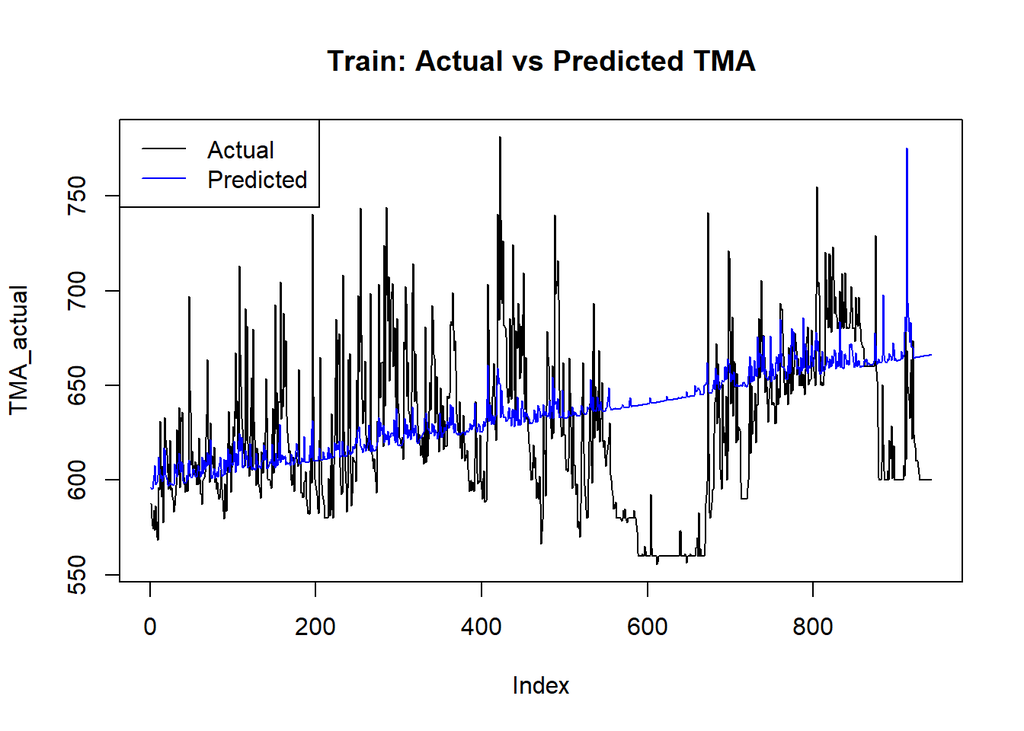

```r
DTMA <- diff(train$Yt, differences = 1)
DPC  <- diff(train$Xt, differences = 1)

train_baru <- data.frame(DPC)
colnames(train_baru) <- c("DPC")

coefs <- summary(modelardl)$coefficients

intercept <- coefs["(Intercept)", "Estimate"]
b1 <- coefs["l.1.DPC", "Estimate"]

train_baru$DTMA_pred <- intercept + b1 * train_baru$DPC

train_baru$TMA_pred <- NA
train_baru$TMA_pred[1] <- train$Yt[1] + train_baru$DTMA_pred[1]

for(i in 2:nrow(train_baru)) {
  train_baru$TMA_pred[i] <- train_baru$TMA_pred[i-1] + train_baru$DTMA_pred[i]
}

TMA_actual <- train$Yt[-1]
TMA_pred <- train_baru$TMA_pred

plot(TMA_actual, type = "l", col = "black", main = "Train: Actual vs Predicted TMA")
lines(TMA_pred, col = "blue")
legend("topleft", legend = c("Actual", "Predicted"), col = c("black", "blue"), lty = 1)
```

```r
MAE <- mean(abs(TMA_pred - TMA_actual), na.rm = TRUE)
RMSE <- sqrt(mean((TMA_pred - TMA_actual)^2, na.rm = TRUE))
MAPE <- mean(abs((TMA_actual - TMA_pred) / TMA_actual), na.rm = TRUE) * 100

cat("MAE:", MAE, "\n")
```

```
## MAE: 32.39134
```

```r
cat("RMSE:", RMSE, "\n")
```

```
## RMSE: 42.26852
```

```r
cat("MAPE:", MAPE, "%\n")
```

```
## MAPE: 5.24862 %
```

Evaluasi Kinerja: * MAE: $32.39134$ * RMSE: $42.26852$ * MAPE: $5.24862\%$

Nilai MAPE sebesar $5.24862\%$ berada di bawah $10\%$, yang menunjukkan bahwa kemampuan model ARDL dalam memprediksi data training termasuk dalam kategori sangat baik (high accuracy).

### 9.4.1 Data Testing

Data pengujian (testing) memiliki $153$ observasi dengan rentang tanggal dari Agustus hingga Desember 2024. Melakukan prosedur peramalan out-of-sample menggunakan data testing dengan menerapkan koefisien model yang sama dan merekonstruksi nilai prediksinya.

```r
str(test)
```

```
## tibble [153 × 3] (S3: tbl_df/tbl/data.frame)
##  $ Date: POSIXct[1:153], format: "2024-08-01" "2024-08-02" ...
##  $ Yt  : num [1:153] 600 665 662 649 632 ...
##  $ Xt  : num [1:153] 8.97 28.38 14.17 6.46 1.9 ...
```

```r
summary(test)
```

```
##       Date                  Yt              Xt
##  Min.   :2024-08-01   Min.   :590.0   Min.   : 0.000
##  1st Qu.:2024-09-08   1st Qu.:598.3   1st Qu.: 0.260
##  Median :2024-10-16   Median :620.0   Median : 2.380
##  Mean   :2024-10-16   Mean   :621.5   Mean   : 6.542
##  3rd Qu.:2024-11-23   3rd Qu.:640.0   3rd Qu.: 8.970
##  Max.   :2024-12-31   Max.   :744.0   Max.   :74.460
```

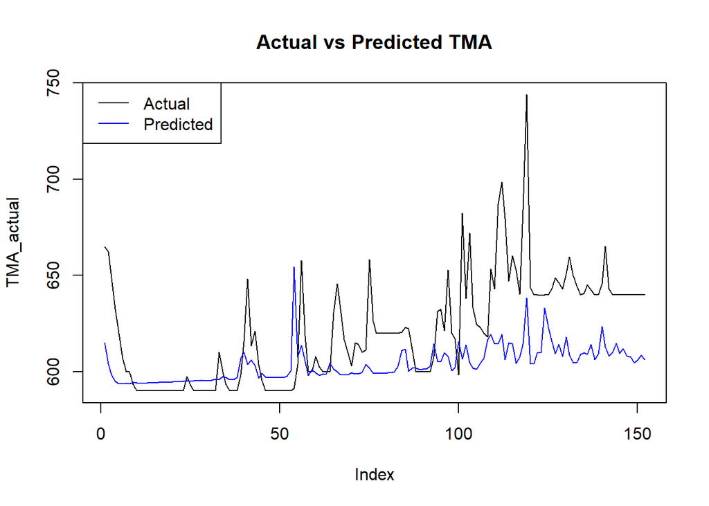

```r
TDPC <- diff(test$Xt, differences = 1)
test_baru <- data.frame(TDPC)
colnames(test_baru) <- c("DPC")

coefs <- summary(modelardl)$coefficients
intercept <- coefs["(Intercept)", "Estimate"]
b1 <- coefs["l.1.DPC", "Estimate"]

test_baru$DTMA_pred <- intercept + b1 * test_baru$DPC

last_TMA_train <- tail(train$Yt, 1)

test_baru$TMA_pred <- NA
test_baru$TMA_pred[1] <- last_TMA_train + test_baru$DTMA_pred[1]

for(i in 2:nrow(test_baru)) {
  test_baru$TMA_pred[i] <- test_baru$TMA_pred[i-1] + test_baru$DTMA_pred[i]
}

TMA_actual <- test$Yt[-1]
TMA_pred <- test_baru$TMA_pred

mse <- mean((TMA_actual - TMA_pred)^2, na.rm = TRUE)
rmse <- sqrt(mse)
date_seq <- seq.Date(from = as.Date("2024-07-25"), by = "day", length.out = length(TMA_pred))

plot(TMA_actual, type = "l", col = "black", main = "Actual vs Predicted TMA")
lines(TMA_pred, col = "blue")
legend("topleft", legend = c("Actual", "Predicted"), col = c("black", "blue"), lty = 1)
```

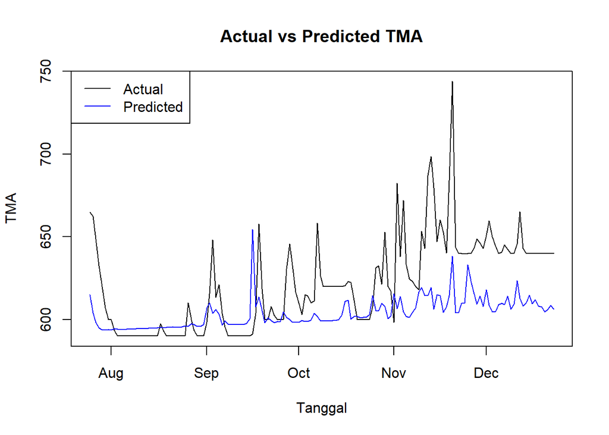

```r
plot(date_seq, TMA_actual, type = "l", col = "black",
     main = "Actual vs Predicted TMA", xlab = "Tanggal", ylab = "TMA")
lines(date_seq, TMA_pred, col = "blue")
legend("topleft", legend = c("Actual", "Predicted"),
       col = c("black", "blue"), lty = 1)
```

```r
MAE <- mean(abs(TMA_pred - TMA_actual))
RMSE <- sqrt(mean((TMA_pred - TMA_actual)^2))
MAPE <- mean(abs((TMA_actual - TMA_pred) / TMA_actual)) * 100

cat("MAE:", MAE, "\n")
```

```
## MAE: 21.66831
```

```r
cat("RMSE:", RMSE, "\n")
```

```
## RMSE: 29.25289
```

```r
cat("MAPE:", MAPE, "%\n")
```

```
## MAPE: 3.369037 %
```

Grafik perbandingan aktual vs prediksi $\text{TMA}$ pada data testing menampilkan tren pergerakan nilai aktual terhadap hasil peramalan berdasar sumbu tanggal.

Evaluasi Kinerja: * MAE: $21.66831$ * RMSE: $29.25289$ * MAPE: $3.369037\%$

Nilai MAPE pada data testing sebesar $3.369037\%$ menunjukkan konsistensi performa model yang sangat baik dan akurat dalam meramalkan data baru di luar data pelatihan.

### 9.4.2 Prediksi 2025

```r
data_prediksi_15 <- read_excel("D:/IPB UNIVERSITY/KULIAH/SEMESTER 5/MPDW/Metode Peramalan Deret Waktu/Pertemuan 3/Data_Jan25_Mar25.xlsx")
data_prediksi_15 <- tail(data_prediksi_15, 120)
data_prediksi_15$Date <- as.Date(data_prediksi_15$Date)
str(data_prediksi_15)
```

```
## tibble [90 × 6] (S3: tbl_df/tbl/data.frame)
##  $ Date: Date[1:90], format: "2025-01-01" "2025-01-02" ...
##  $ TMA : num [1:90] 641 640 640 640 640 ...
##  $ PC  : num [1:90] 5.27 2.45 6.22 6.03 2.63 ...
##  $ TM  : num [1:90] 24.6 25 25.3 25.1 24.9 ...
##  $ RH  : num [1:90] 88 85.2 85.5 86.4 84.6 ...
##  $ WS  : num [1:90] 2.56 1.85 1.75 2.56 2.38 1.82 1.87 2.22 1.64 1.64 ...
```

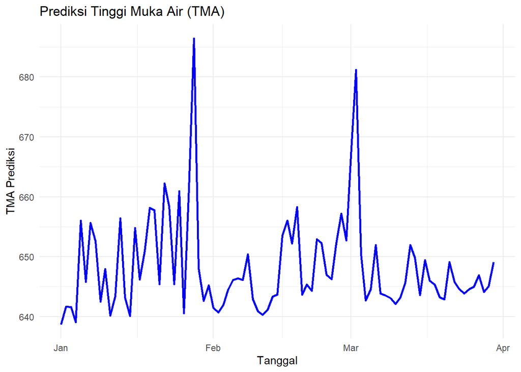

```r
DPC_15 <- diff(data_prediksi_15$PC, differences = 1)
test_15 <- data.frame(DPC = DPC_15)
colnames(test_15) <- c("DPC")

coefs <- summary(modelardl)$coefficients
intercept <- coefs["(Intercept)", "Estimate"]
b1 <- coefs["l.1.DPC", "Estimate"]

test_15$DTMA_pred <- intercept + b1 * test_15$DPC

test_15$TMA_pred <- NA
test_15$TMA_pred[1] <- data_prediksi_15$TMA[1] + test_15$DTMA_pred[1]

for(i in 2:nrow(test_15)) {
  test_15$TMA_pred[i] <- test_15$TMA_pred[i-1] + test_15$DTMA_pred[i]
}

tanggal_prediksi <- seq.Date(from = as.Date("2025-01-01"), by = "day", length.out = nrow(test_15))
hasil_prediksi <- data.frame(
  date = tanggal_prediksi,
  TMA_actual = data_prediksi_15$TMA[-1],
  TMA_pred = test_15$TMA_pred
)

nama_file_excel4 <- "hasil_peramalan.xlsx"
write_xlsx(hasil_prediksi, path = nama_file_excel4)

ggplot(hasil_prediksi, aes(x = date, y = TMA_pred)) +
  geom_line(color = "blue", linewidth = 1) +
  labs(
    title = "Prediksi Tinggi Muka Air (TMA)",
    x = "Tanggal",
    y = "TMA Prediksi"
  ) +
  theme_minimal()
```

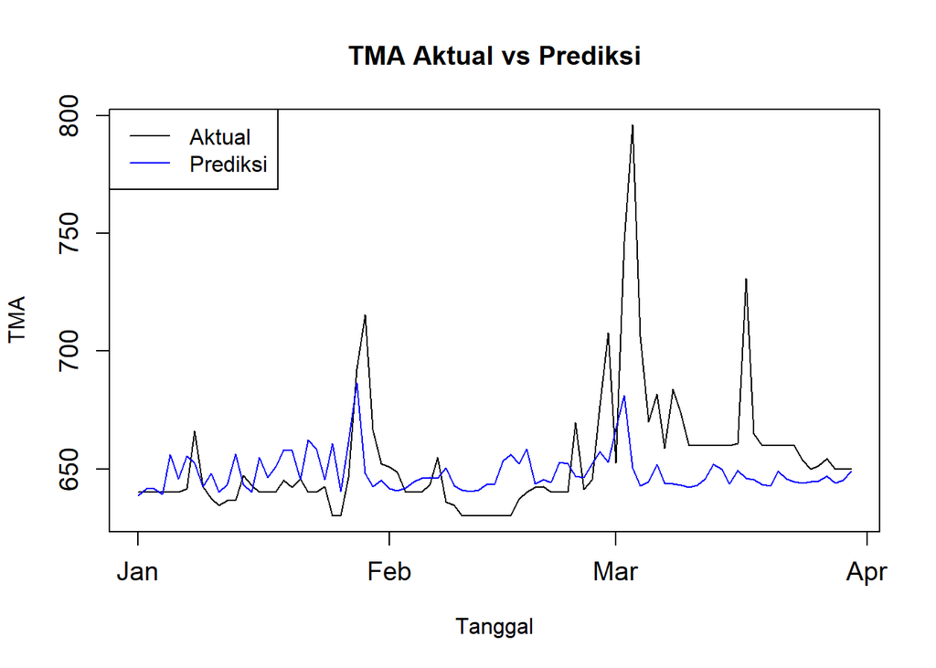

```r
plot(hasil_prediksi$date, hasil_prediksi$TMA_actual, type = "l", col = "black",
     ylab = "TMA", xlab = "Tanggal", main = "TMA Aktual vs Prediksi", cex.axis = 1.2)
lines(hasil_prediksi$date, hasil_prediksi$TMA_pred, col = "blue")
legend("topleft", legend = c("Aktual", "Prediksi"), col = c("black", "blue"), lty = 1)
```

```r
MAE <- mean(abs(hasil_prediksi$TMA_actual - hasil_prediksi$TMA_pred))
RMSE <- sqrt(mean((hasil_prediksi$TMA_actual - hasil_prediksi$TMA_pred)^2))
MAPE <- mean(abs((hasil_prediksi$TMA_actual - hasil_prediksi$TMA_pred) / hasil_prediksi$TMA_actual)) * 100

cat("MAE:", MAE, "\n")
```

```
## MAE: 16.44957
```

```r
cat("RMSE:", RMSE, "\n")
```

```
## RMSE: 26.22874
```

```r
cat("MAPE:", MAPE, "%\n")
```

```
## MAPE: 2.423865 %
```

Visualisasi Grafik ggplot: Plot menggunakan ggplot2 menampilkan garis tren berwarna biru untuk “Prediksi Tinggi Muka Air (TMA)” sepanjang bulan Januari hingga April 2025.

Plot Perbandingan Aktual vs Prediksi: Grafik base R memperlihatkan perbandingan langsung antara kurva hitam (TMA Aktual) dan kurva biru (TMA Prediksi) untuk periode tahun 2025.

Evaluasi Kinerja Peramalan 2025: * MAE: $16.44957$ * RMSE: $26.22874$ * MAPE: $2.423865\%$

Nilai MAPE sebesar $2.423865\%$ berada jauh di bawah ambang batas $10\%$, yang mengindikasikan bahwa model ARDL memiliki tingkat akurasi peramalan yang sangat tinggi dan sangat baik dalam memproyeksikan tinggi muka air untuk periode tahun 2025.

# 10 Kesimpulan dan Saran

## 10.2 Saran

Secara keseluruhan, model **ARDL** dinobatkan sebagai model terbaik dan paling andal untuk memprediksi fluktuasi tinggi muka air berdasarkan pola curah hujan. Model ini sangat direkomendasikan untuk digunakan sebagai dasar sistem peringatan dini (*early warning system*) maupun pengambil kebijakan dalam mitigasi risiko banjir dan pengelolaan sumber daya air.